# Reproducible Research: Peer Assessment 1

## Loading and preprocessing the data

Download the data:

```r
fileurl="https://d396qusza40orc.cloudfront.net/repdata%2Fdata%2Factivity.zip"
download.file(fileurl,destfile = "activity.zip")
unzip("activity.zip")
```

Load data into R:

```r
activitydata=read.csv("activity.csv")
head(activitydata)
```

```
##   steps       date interval
## 1    NA 2012-10-01        0
## 2    NA 2012-10-01        5
## 3    NA 2012-10-01       10
## 4    NA 2012-10-01       15
## 5    NA 2012-10-01       20
## 6    NA 2012-10-01       25
```

## What is mean total number of steps taken per day?

Let’s first calcuate the total number of steps taken per day. The mission values are ignored.

```r
#remove NAs
activitydata2=activitydata[complete.cases(activitydata),]
#caluate the sum of steps per day
totalperday=tapply(activitydata2$steps,activitydata2$date,sum)
```

Here is a histogram of the total number of steps taken each day

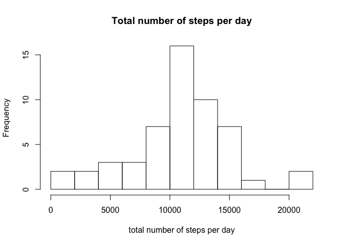

```r
hist(totalperday,breaks=10,xlab = "total number of steps per day", main = "Total number of steps per day")
```

The mean of the total number of steps taken per day is:

```r
mean_steps=mean(totalperday,na.rm=TRUE)
print(mean_steps)
```

```
## [1] 10766.19
```

The median of the total number of steps taken per day is:

```r
median_steps=median(totalperday,na.rm=TRUE)
print(median_steps)
```

```
## [1] 10765
```

## What is the average daily activity pattern?

Here is a time series plot of the 5-minute interval (x-axis) and the average number of steps taken, averaged across all days (y-axis)

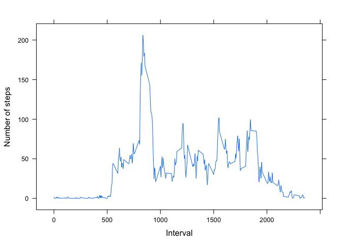

```r
#calculate the average number of steps across all days
activitydata2=transform(activitydata2,interval=factor(interval))
average_steps=tapply(activitydata2$steps, activitydata2$interval, mean)
average_steps=unname(average_steps)
dailypattern=data.frame("interval"=activitydata$interval[1:288],"average_steps"=average_steps)
#make the plot
library(lattice)
xyplot(average_steps~interval,data = dailypattern,type="l",xlab = "Interval",ylab ="Number of steps")
```

The 5-minute inteval that containing the maxium number of steps,averaged across all days:

```r
max_index=which.max(dailypattern$average_steps)
max_interval=dailypattern[max_index,1]
print(max_interval)
```

```
## [1] 835
```

## Imputing missing values

The total number of missing values in the dataset is:

```r
total_na=sum(!complete.cases(activitydata))
print(total_na)
```

```
## [1] 2304
```

Create a new dataset that is equal to the original dataset but with the missing data filled in with the mean for that 5-minute interval.

```r
new_activity=activitydata
for (i in 1:nrow(new_activity)){
        if (is.na(new_activity$steps[i])){
                j=i%%nrow(average_steps)
                if(j==0){
                        j=nrow(average_steps)
                }
                new_activity$steps[i]=average_steps[j]
        }
}
```

Here is a histogram of the total number of steps taken each day for the new dataset:

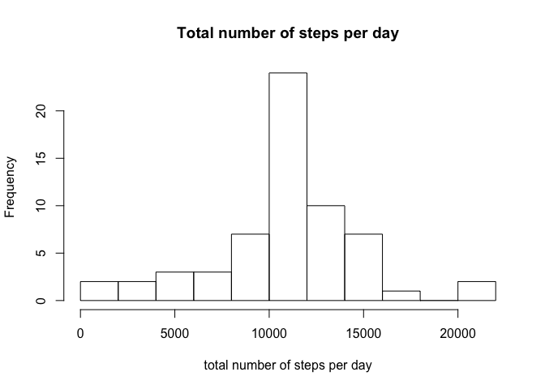

```r
#calculate the total number of steps taken each day for the new dataset
new_total_day=tapply(new_activity$steps,new_activity$date,sum)
new_total_day=unname(new_total_day)
#make the histogram
hist(new_total_day,breaks=10,xlab = "total number of steps per day", main = "Total number of steps per day")
```

The mean of the total number of steps taken per day for new dataset is:

```r
new_mean_steps=mean(new_total_day)
print(new_mean_steps)
```

```
## [1] 10766.19
```

```r
print("Does the mean differ from the first part of the assignment:")
```

```
## [1] "Does the mean differ from the first part of the assignment:"
```

```r
print((!new_mean_steps==mean_steps))
```

```
## [1] FALSE
```

The median of the total number of steps taken per day for new dataset is:

```r
new_median_steps=median(new_total_day)
print(new_median_steps)
```

```
## [1] 10766.19
```

```r
print("Does the median differ from the first part of the assignment:")
```

```
## [1] "Does the median differ from the first part of the assignment:"
```

```r
print((!new_median_steps==median_steps))
```

```
## [1] TRUE
```

## Are there differences in activity patterns between weekdays and weekends?

Create a new factor variable in the dataset with two levels – “weekday” and “weekend” indicating whether a given date is a weekday or weekend day.

```r
#convert $date from factor to date
new_activity=transform(new_activity,date=as.Date(date))
#create weekday variable
new_activity$weekday=weekdays(new_activity$date)
new_activity=transform(new_activity,weekday=factor(weekday))
levels(new_activity$weekday)=c("weekday","weekday","weekend","weekend","weekday","weekday","weekday")
```

Make a panel plot containing a time series plot of the 5-minute interval (x-axis) and the average number of steps taken, averaged across all weekday days or weekend days (y-axis).

```r
library(dplyr)
```

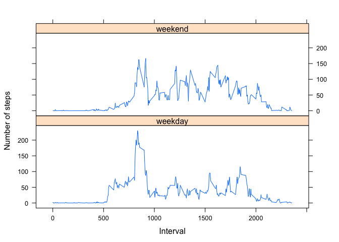

```r
library(lattice)
#filter the data for weekdays and weekends
weekday_activity=filter(new_activity,weekday=="weekday")
weekend_activity=filter(new_activity,weekday=="weekend")
#calcuate daily average steps for weekdays and weekends
weekday_steps=with(weekday_activity,tapply(steps, interval, mean))
weekday_steps=unname(weekday_steps)
weekend_steps=with(weekend_activity,tapply(steps, interval, mean))
weekend_steps=unname(weekend_steps)
weekday_steps=data.frame("interval"=new_activity$interval[1:288],"average_steps"=weekday_steps,"weekday"=factor("weekday"))
weekend_steps=data.frame("interval"=new_activity$interval[1:288],"average_steps"=weekend_steps,"weekday"=factor("weekend"))
#combine weekday and weekend daily steps into one data frame
daily_steps=rbind(weekday_steps,weekend_steps)
#make panel plot
xyplot(average_steps~interval|weekday,data = daily_steps,layout=c(1,2),xlab = "Interval",ylab = "Number of steps",type="l")
```